# Homework-03

Julie Jung

October 3, 2017

Load in the dataset “zombies.csv” from my GitHub repo at https://github.com/fuzzyatelin/fuzzyatelin.github.io/tree/master/AN597_Fall17/. This data includes the first and last name and gender of the entire population of 1000 people who have survived the zombie apocalypse and are now ekeing out an existence somewhere on the East Coast, along with several other variables (height, weight, age, number of years of education, number of zombies they have killed, and college major see here for info on important post-zombie apocalypse majors

```r
library(curl)
f <- f <- curl("https://raw.githubusercontent.com/fuzzyatelin/fuzzyatelin.github.io/master/AN597_Fall17/zombies.csv")
d <- read.csv(f, header = TRUE, sep = ",", stringsAsFactors = FALSE)
head(d)
```

```
##   id first_name last_name gender   height   weight zombies_killed
## 1  1      Sarah    Little Female 62.88951 132.0872              2
## 2  2       Mark    Duncan   Male 67.80277 146.3753              5
## 3  3    Brandon     Perez   Male 72.12908 152.9370              1
## 4  4      Roger   Coleman   Male 66.78484 129.7418              5
## 5  5      Tammy    Powell Female 64.71832 132.4265              4
## 6  6    Anthony     Green   Male 71.24326 152.5246              1
##   years_of_education                           major      age
## 1                  1                medicine/nursing 17.64275
## 2                  3 criminal justice administration 22.58951
## 3                  1                       education 21.91276
## 4                  6                  energy studies 18.19058
## 5                  3                       logistics 21.10399
## 6                  4                  energy studies 21.48355
```

[1] Calculate the population mean and standard deviation for each quantitative random variable (height, weight, age, number of zombies killed, and years of education). NOTE: You will NOT want to use the built in var() and sd() commands as these are for samples.

```r
# This is in module 8
# Note: We don’t use the sd() function as this would divide by length(x)-1.

attach(d)

pop.mean <- c(mean(height), mean(weight), mean(age), mean(zombies_killed), mean(years_of_education))

pop.sd <- c(sqrt(sum((height - mean(height))^2)/length(height)),
            sqrt(sum((weight - mean(weight))^2)/length(weight)),
            sqrt(sum((age - mean(age))^2)/length(age)),
            sqrt(sum((zombies_killed - mean(zombies_killed))^2)/length(zombies_killed)),
            sqrt(sum((years_of_education - mean(years_of_education))^2)/length(years_of_education)))
detach(d)
```

[2] Use {ggplot} and make boxplots of each of these variables by gender.

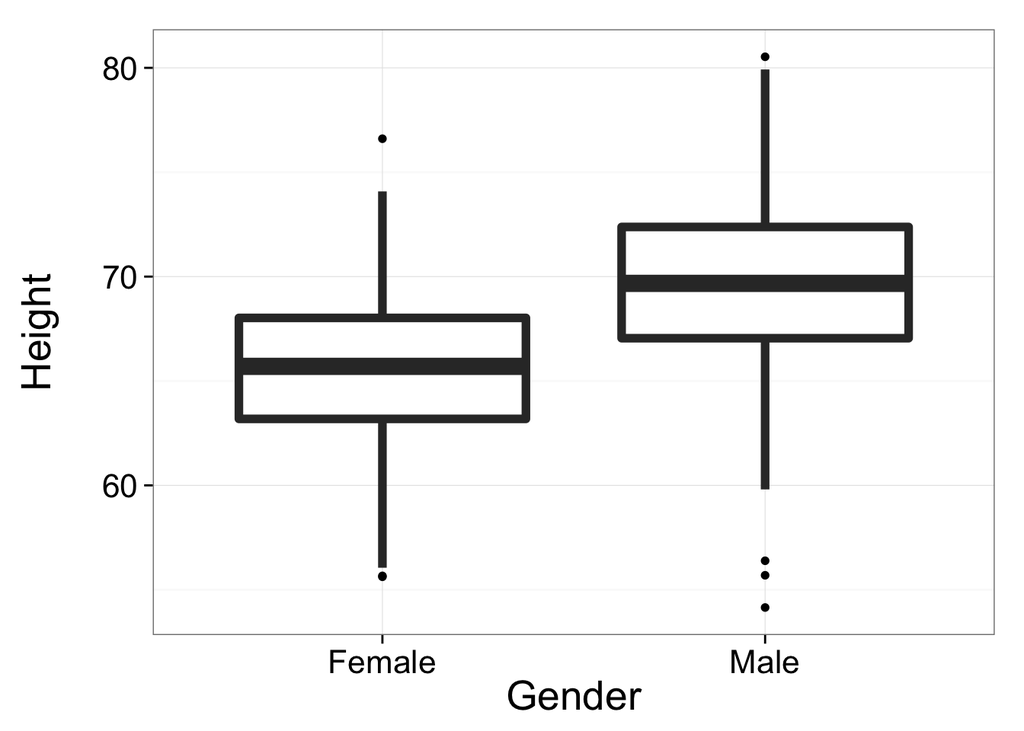

```r
library(ggplot2)
ggplot(d, aes(x=gender, y=height)) +
  geom_boxplot(size=2) +
  ylab("Height\n")+
  theme_bw(20) +
  xlab("Gender")
```

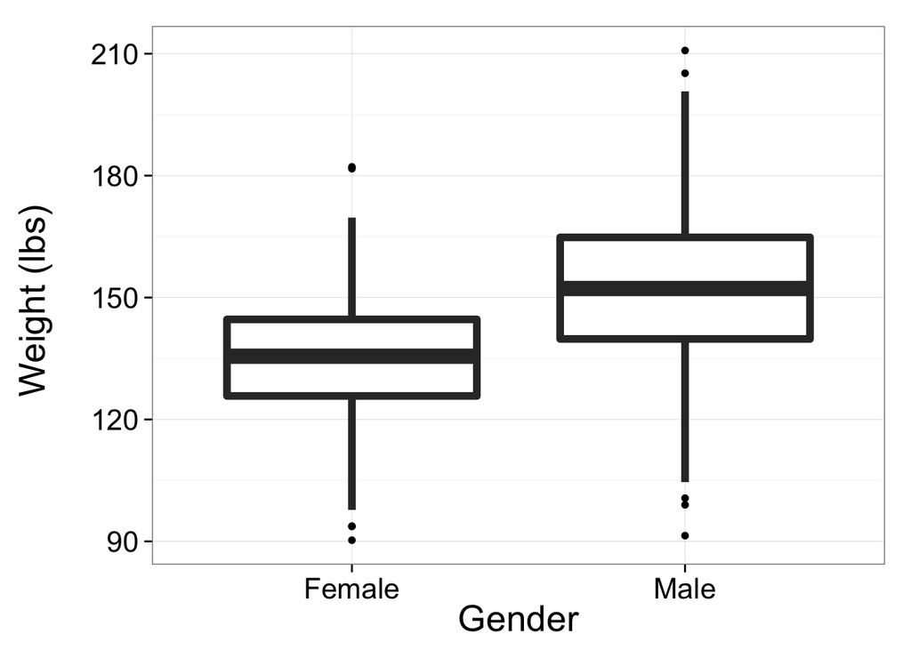

```r
ggplot(d, aes(x=gender, y=weight)) +
  geom_boxplot(size=2) +
  ylab("Weight (lbs) \n")+
  theme_bw(20) +
  xlab("Gender")
```

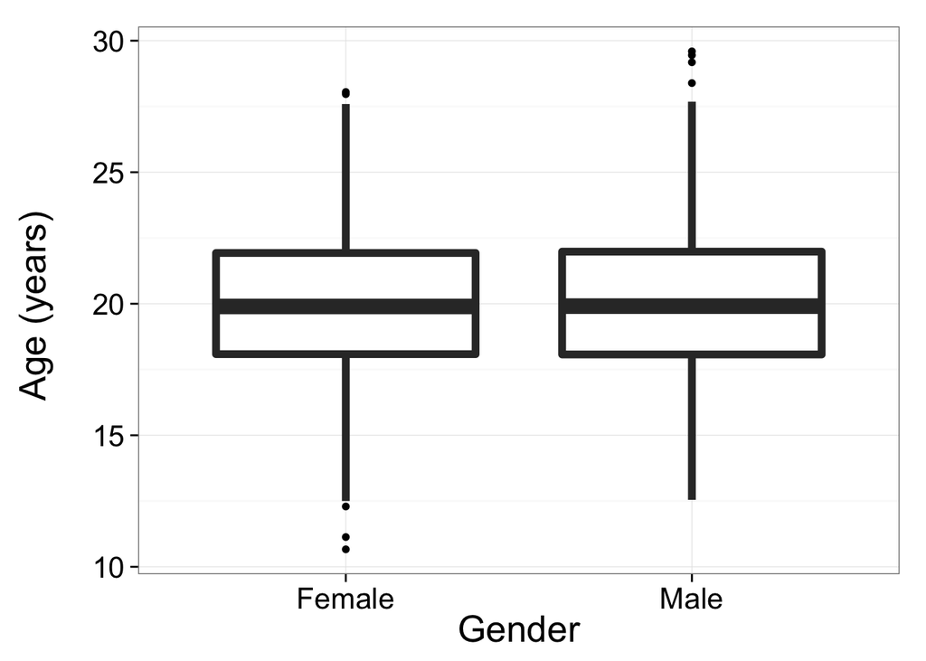

```r
ggplot(d, aes(x=gender, y=age)) +
  geom_boxplot(size=2) +
  ylab("Age (years) \n")+
  theme_bw(20) +
  xlab("Gender")
```

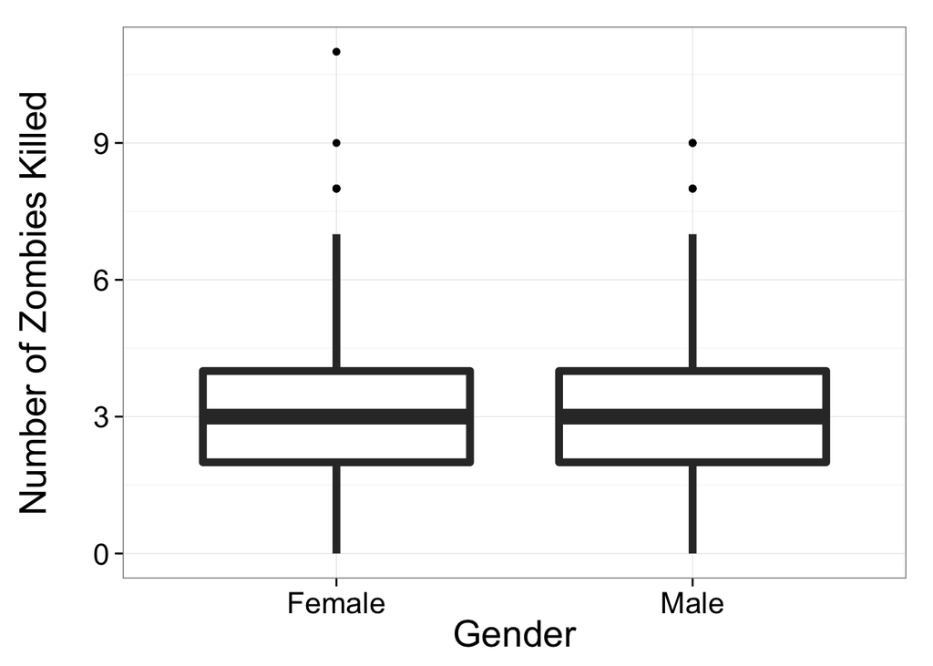

```r
ggplot(d, aes(x=gender, y=zombies_killed)) +
  geom_boxplot(size=2) +
  ylab("Number of Zombies Killed\n")+
  theme_bw(20) +
  xlab("Gender")
```

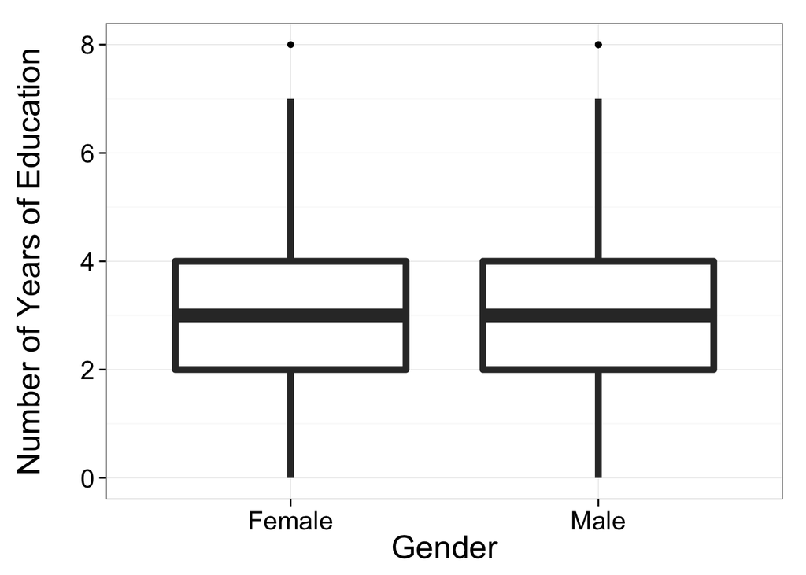

```r
ggplot(d, aes(x=gender, y=years_of_education)) +
  geom_boxplot(size=2) +
  ylab("Number of Years of Education\n")+
  theme_bw(20) +
  xlab("Gender")
```

[3] Use {ggplot} and make scatterplots of height and weight in relation to age. Do these variables seem to be related? In what way?

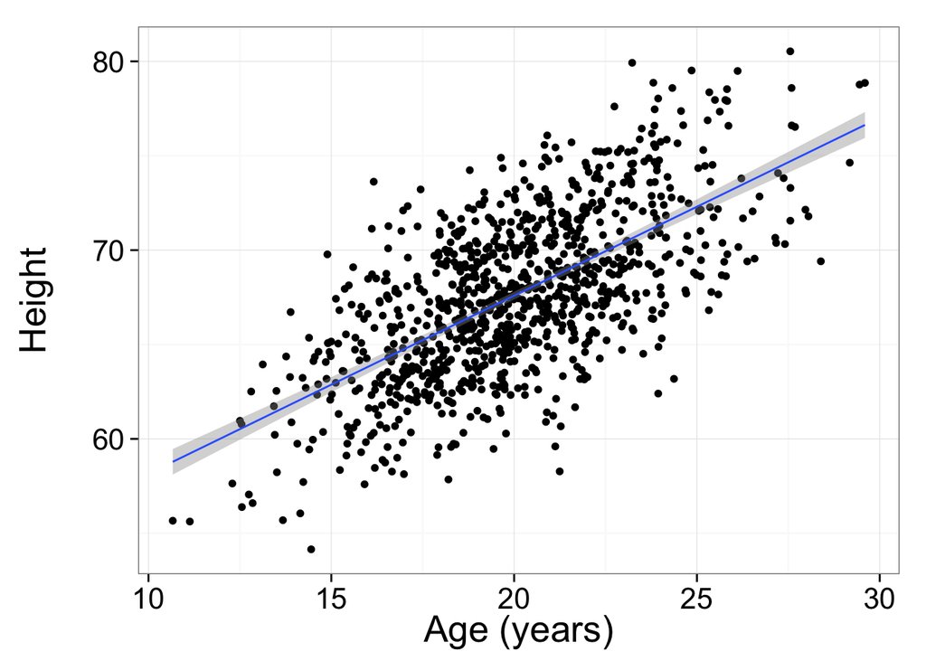

```r
ggplot(d, aes(x=age, y=height)) +
  geom_point(size=2) +
  geom_smooth(method=lm) +
  ylab("Height\n")+
  theme_bw(20) +
  xlab("Age (years)")
```

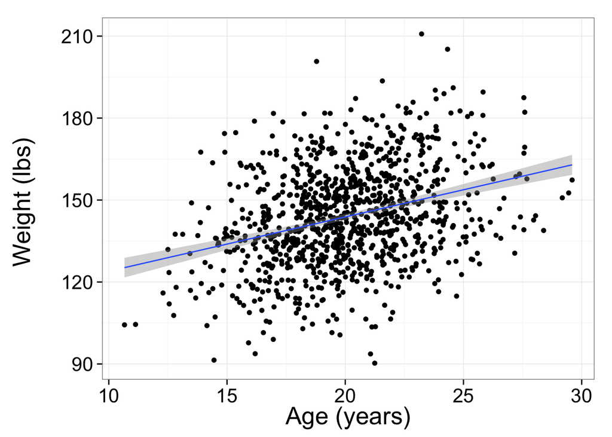

```r
ggplot(d, aes(x=age, y=weight)) +
  geom_point(size=2) +
  geom_smooth(method=lm) +
  ylab("Weight (lbs) \n")+
  theme_bw(20) +
  xlab("Age (years)")
```

Both height and weight share a positive linear relationship with age, and with each other.

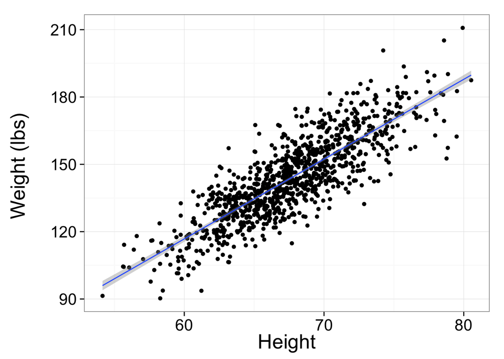

```r
ggplot(d, aes(x=height, y=weight)) +
  geom_point(size=2) +
  geom_smooth(method=lm) +
  ylab("Weight (lbs) \n")+
  theme_bw(20) +
  xlab("Height")
```

[4] Using histograms and Q-Q plots, check whether the quantitative variables seem to be drawn from a normal distribution. Which seem to be and which do not (hint: not all are drawn from the normal distribution)? For those that are not, can you determine what common distribution they are drawn from?

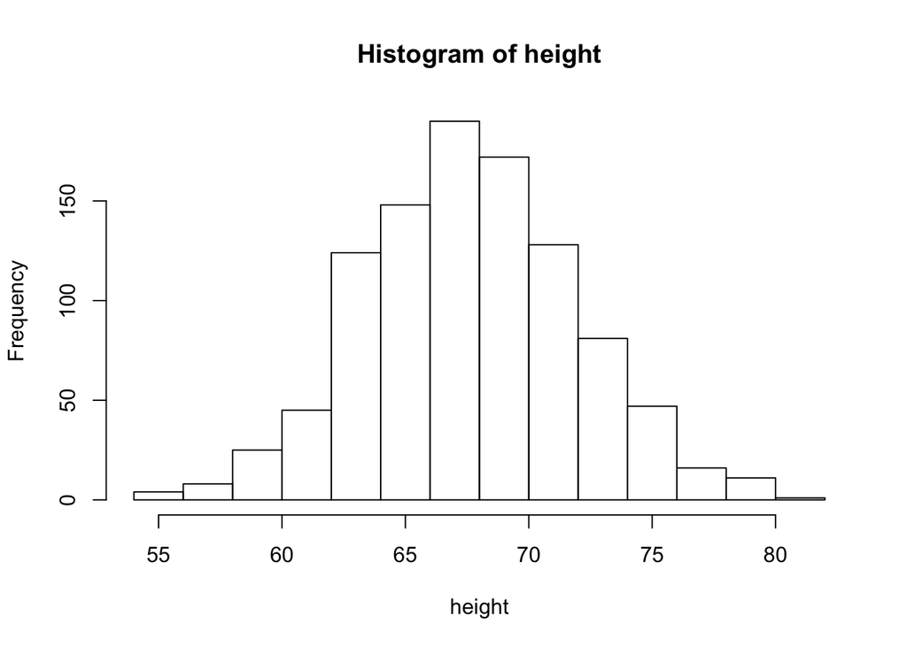

```r
attach(d)
hist(height) #normal
```

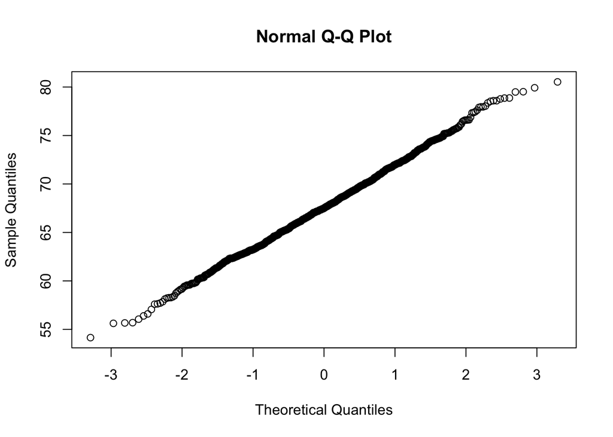

```r
qqnorm(height) #normal
```

```r
shapiro.test(height) #normal
```

```
##
##  Shapiro-Wilk normality test
##
## data:  height
## W = 0.9985, p-value = 0.5631
```

Height is drawn from a normal distribution.

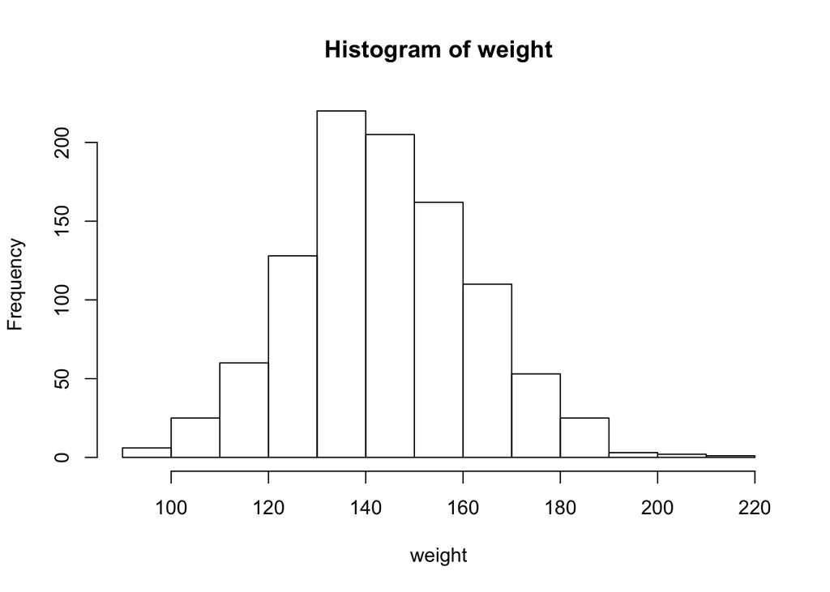

```r
hist(weight) #skewed - long right tail
```

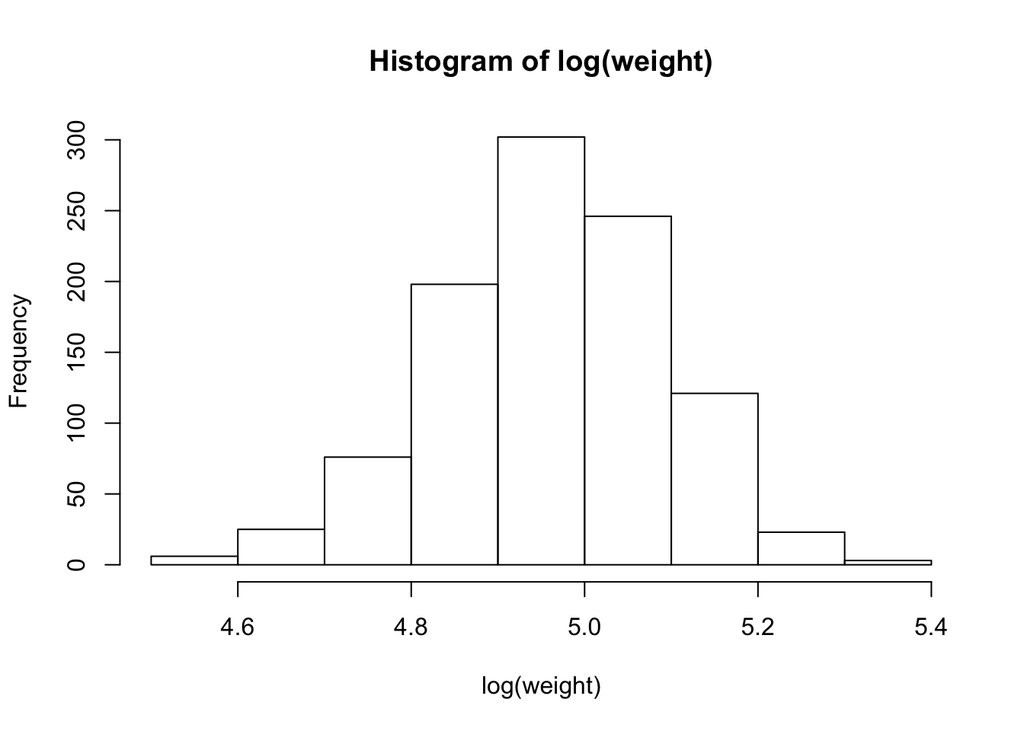

```r
hist(log(weight)) # now looks normal
```

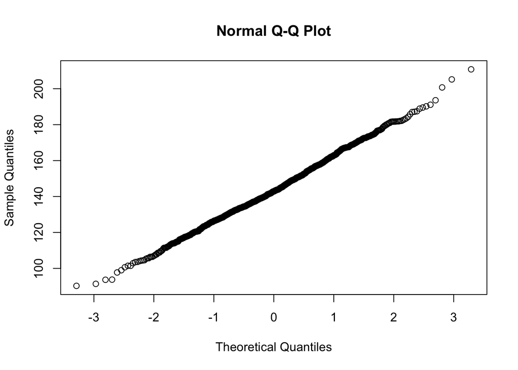

```r
qqnorm(weight) #normal
```

```r
shapiro.test(weight) # normal
```

```
##
##  Shapiro-Wilk normality test
##
## data:  weight
## W = 0.9978, p-value = 0.1997
```

Weight is drawn from a skewed normal distribution.

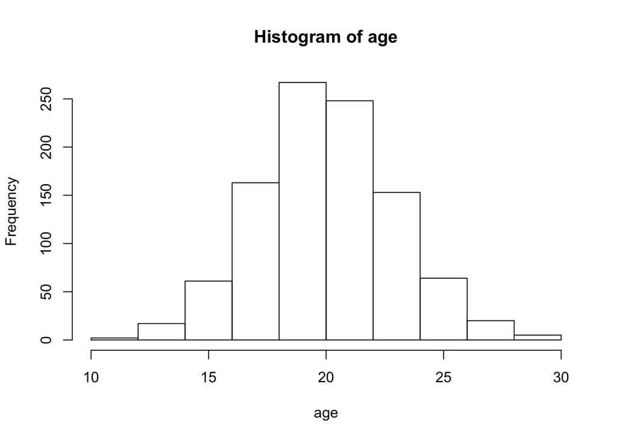

```r
hist(age) #normal
```

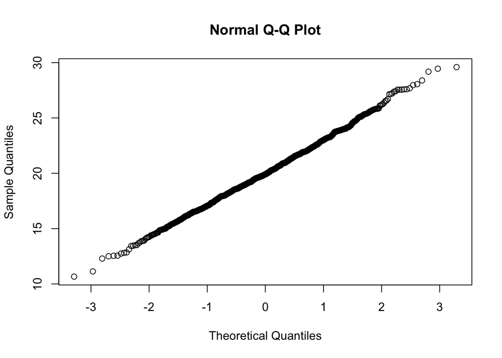

```r
qqnorm(age) #normal
```

```r
shapiro.test(age) # normal
```

```
##
##  Shapiro-Wilk normality test
##
## data:  age
## W = 0.9982, p-value = 0.386
```

Age is drawn from a normal distribution.

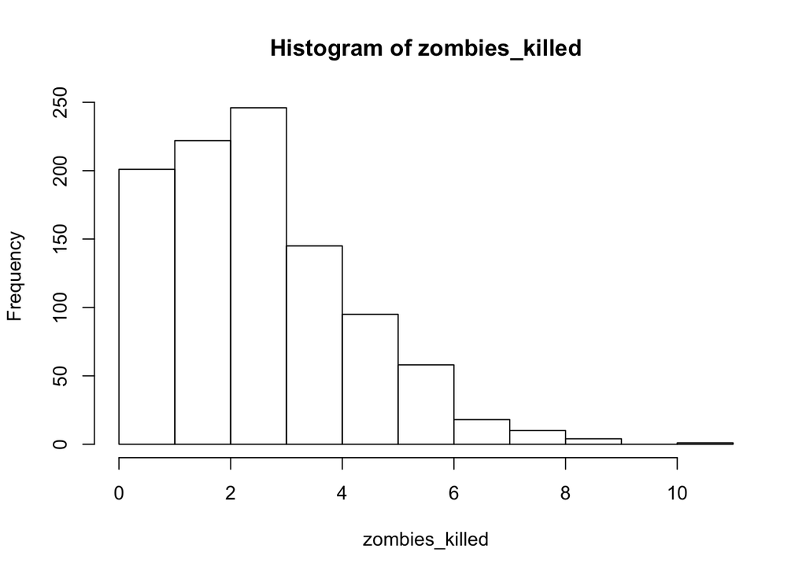

```r
hist(zombies_killed) #not normal
```

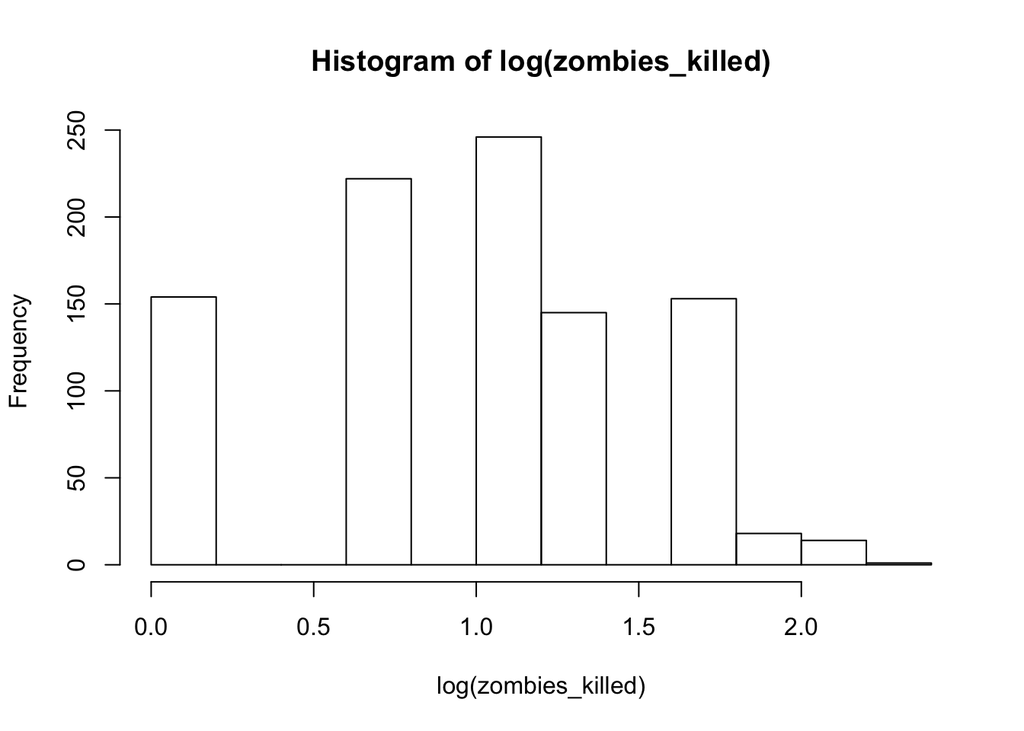

```r
hist(log(zombies_killed)) # still not normal
```

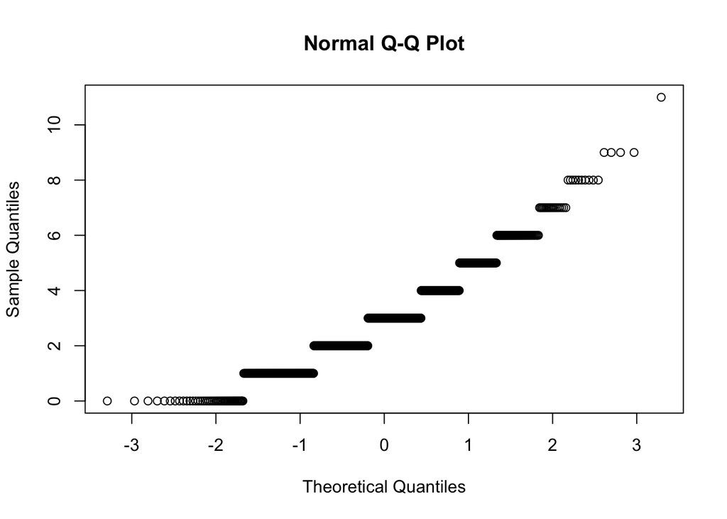

```r
qqnorm(zombies_killed) # not normal - in steps
```

```r
shapiro.test(zombies_killed) # def not normal
```

```
##
##  Shapiro-Wilk normality test
##
## data:  zombies_killed
## W = 0.9434, p-value < 2.2e-16
```

Zombies killed is drawn from a binomial distribution, typically used to model the probability of a number of “successes” k out of a set of “trials” n, i.e., for counts of a particular outcome.

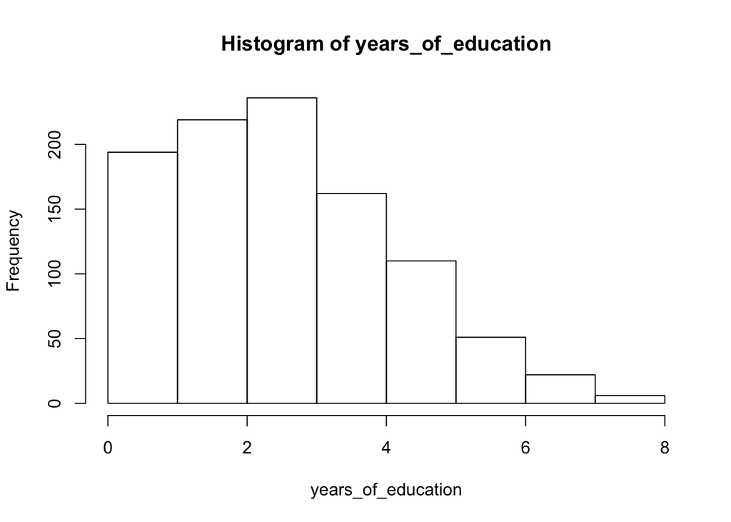

```r
hist(years_of_education) #not normal
```

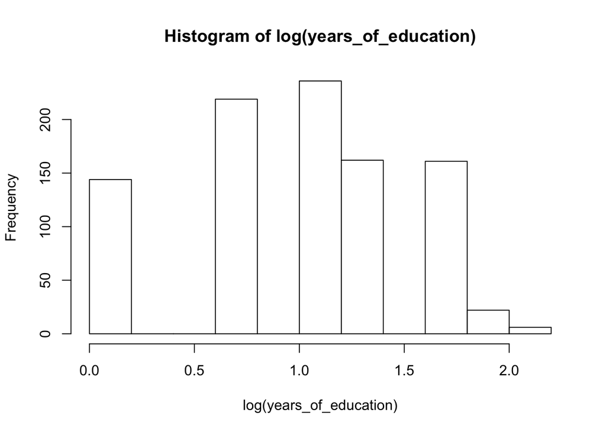

```r
hist(log(years_of_education)) # still not normal
```

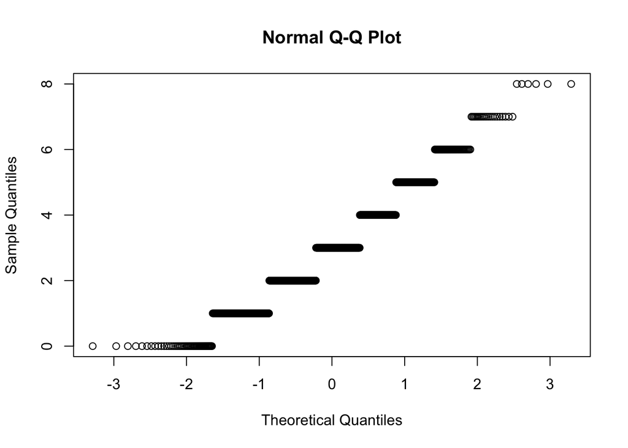

```r
qqnorm(years_of_education) # not normal - in steps
```

```r
shapiro.test(years_of_education) # def not normal
```

```
##
##  Shapiro-Wilk normality test
##
## data:  years_of_education
## W = 0.9544, p-value < 2.2e-16
```

```r
detach(d)
```

Years of education is drawn from a poisson distribution, often used to model open ended counts of independently occuring events, for example the number of cars that pass a traffic intersection over a given interval of time or the number of times a monkey scratches itself during a given observation interval.

[5] Now use the sample() function to sample ONE subset of 30 zombie survivors (without replacement) from this population and calculate the mean and sample standard deviation for each variable. Also estimate the standard error for each variable and construct the 95% confidence interval for each mean. Note that for the variables that are not drawn from the normal distribution, you will need to base your estimate of the CIs on some different distribution.

```r
# This is in module 8.

#use the sample() function to sample ONE subset of 30 zombie survivors (without replacement) from this population
sample_height<- sample(d$height, size = 30)
sample_weight<- sample(d$weight, size = 30)
sample_age<- sample(d$age, size = 30)
sample_zombies_killed<- sample(d$zombies_killed, size = 30)
sample_years_of_education<- sample(d$years_of_education, size = 30)

#calculate the mean and sample standard deviation for each variable.

mean(sample_height)
```

```
## [1] 67.25303
```

```r
mean(sample_weight)
```

```
## [1] 145.6929
```

```r
mean(sample_age)
```

```
## [1] 20.30443
```

```r
mean(sample_zombies_killed)
```

```
## [1] 3.733333
```

```r
mean(sample_years_of_education)
```

```
## [1] 2.566667
```

```r
sd(sample_height)
```

```
## [1] 4.48322
```

```r
sd(sample_weight)
```

```
## [1] 16.39689
```

```r
sd(sample_age)
```

```
## [1] 2.415872
```

```r
sd(sample_zombies_killed)
```

```
## [1] 2.420221
```

```r
sd(sample_years_of_education)
```

```
## [1] 1.633345
```

```r
#Also estimate the standard error for each variable and construct the 95% confidence interval for each mean.

library(sciplot)
se(sample_height)
```

```
## [1] 0.8185202
```

```r
se(sample_weight)
```

```
## [1] 2.99365
```

```r
se(sample_age)
```

```
## [1] 0.4410759
```

```r
se(sample_zombies_killed)
```

```
## [1] 0.4418699
```

```r
se(sample_years_of_education)
```

```
## [1] 0.2982066
```

```r
library(Rmisc)
CI(rnorm(sample_height))
```

```
##       upper        mean       lower
##  0.32065331 -0.08562113 -0.49189558
```

```r
CI(rnorm(sample_weight))
```

```
##       upper        mean       lower
##  0.46209987  0.04142195 -0.37925597
```

```r
CI(rnorm(sample_age))
```

```
##      upper       mean      lower
##  0.2075044 -0.1586043 -0.5247130
```

```r
#Calculating CIs by bootstrapping (module 7)

## sample_zombies_killed
set <- NULL # sets up a dummy variable to hold our 10000 simulations
n <- 30
for (i in 1:10000) {
    set[i] <- mean(sample(sample_zombies_killed, n, replace = FALSE))
}
quantile(set, c(0.05, 0.95))
```

```
##       5%      95%
## 3.733333 3.733333
```

```r
## sample_years_of_education
set <- NULL # sets up a dummy variable to hold our 10000 simulations
n <- 30
for (i in 1:10000) {
    set[i] <- mean(sample(sample_years_of_education, n, replace = FALSE))
}
quantile(set, c(0.05, 0.95))
```

```
##       5%      95%
## 2.566667 2.566667
```

[6] Now draw 99 more random samples of 30 zombie survivors out and calculate the mean for each of the these samples. Together with the first sample you drew out, you now have a set of 100 means for each variable (each based on 30 observations), which constitutes a sampling distribution for each variable. What are the means and standard deviations of this distribution for each variable? How do the standard deviations compare to the standard errors estimated in [5]? What do these sampling distributions look like? Are they normally distributed? What about for those variables that you concluded were not originally drawn from a normal distribution?

# For height:

```r
k <- 100  # number of samples
n <- 30  # size of each sample
s <- NULL  # dummy variable to hold each sample
for (i in 1:k) {
    s[[i]] <- sample(d$height, size = n, replace = FALSE)
}
head(s)
```

```
## [[1]]
##  [1] 64.25954 70.64534 62.43483 75.85361 69.29227 60.87037 70.21352
##  [8] 64.18962 61.95252 67.43631 69.08494 64.05988 68.29221 71.72562
## [15] 76.60479 71.59179 70.44371 70.55803 65.21987 65.41359 65.07139
## [22] 57.85084 62.06469 71.31852 70.79582 72.95424 64.64341 63.70855
## [29] 65.94479 68.37091
##
## [[2]]
##  [1] 66.95127 64.33214 64.38058 69.54824 68.23992 71.72426 79.51505
##  [8] 72.82977 70.66565 66.54655 70.16329 62.61715 74.13331 70.65781
## [15] 62.61210 63.41696 73.62638 61.58678 62.76865 62.20613 68.50593
## [22] 71.79126 62.33275 70.11203 65.14789 63.74886 68.67496 64.79030
## [29] 72.14192 70.13980
##
## [[3]]
```

[output cut: 26 more lines]

```r
# What are the means and standard deviations of this distribution for each variable?
#calc a mean height
m <- NULL
for (i in 1:k) {
    m[i] <- mean(s[[i]])
}
mean(m)
```

```
## [1] 67.67515
```

```r
sd(m)
```

```
## [1] 0.7607263
```

```r
#How do the standard deviations compare to the standard errors estimated in [5]?
se(sample_height) #SD slightly less than SE
```

```
## [1] 0.8185202
```

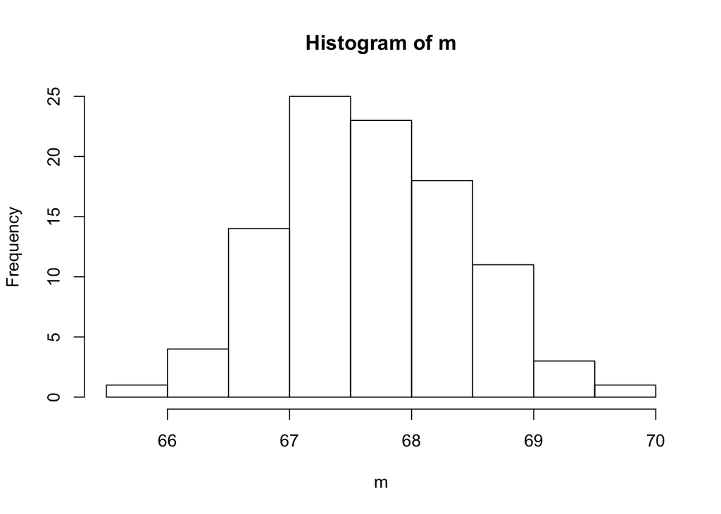

```r
# What do these sampling distributions look like?
hist(m) #normal
```

# For weight:

```r
k <- 100  # number of samples
n <- 30  # size of each sample
s <- NULL  # dummy variable to hold each sample
for (i in 1:k) {
    s[[i]] <- sample(d$weight, size = n, replace = FALSE)
}
head(s)
```

```
## [[1]]
##  [1] 133.4684 152.0145 147.3089 157.3538 120.7950 156.1133 105.3084
##  [8] 165.4885 133.0025 132.8239 169.1259 153.9619 166.1259 116.4600
## [15] 142.6842 167.9066 148.0729 156.0241 148.9743 114.5466 125.8278
## [22] 124.5944 117.4699 146.1715 144.1175 141.7290 163.0375 141.3045
## [29] 129.7149 107.1929
##
## [[2]]
##  [1] 164.48874 139.23583 135.10144  97.74513 167.00176 140.65221 136.00112
##  [8] 104.58108 111.49075 143.49534 150.55786 158.64966 148.51320 179.48473
## [15] 128.37587 128.59654 113.00907 182.14998 147.18906 140.05055 136.76233
## [22] 150.78733 125.61392 124.31422 147.95051 146.03713 136.55417 124.79954
## [29] 142.68420 118.89911
##
## [[3]]
```

[output cut: 26 more lines]

```r
#calc a mean weight
m <- NULL
for (i in 1:k) {
    m[i] <- mean(s[[i]])
}
mean(m)
```

```
## [1] 144.3255
```

```r
sd(m)
```

```
## [1] 3.281335
```

```r
#How do the standard deviations compare to the standard errors estimated in [5]?
se(sample_weight) #SD is slightly higher than estimated SE
```

```
## [1] 2.99365
```

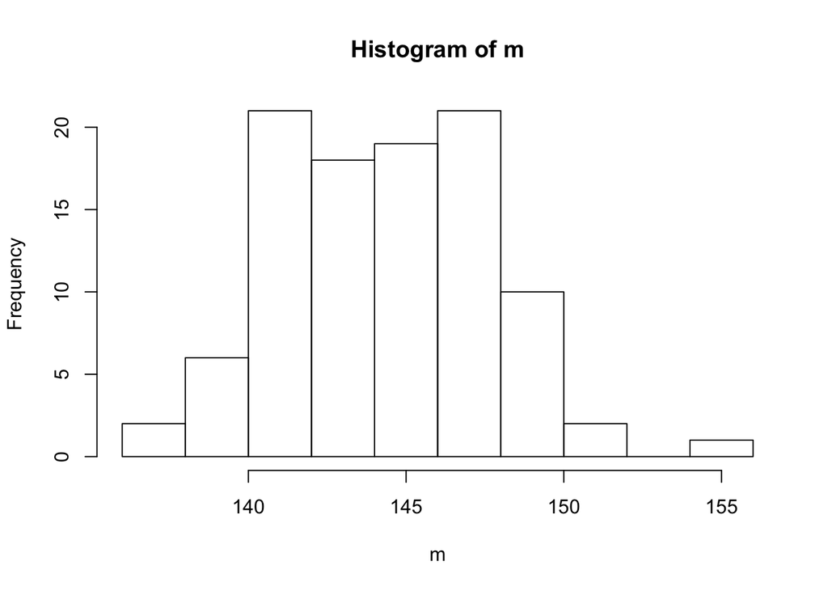

```r
# What do these sampling distributions look like?
hist(m) #normal
```